# Data Fanny: comparison with expression and proteomic datasets

Marie Locard-Paulet

20 novembre 2015

The comparison of Treg and Tconv has been done previously at the proteomic and transcriptomic level. Here I want to compare our dataset with previous works. I will work with the supplementary data of two papers:

- Foxp3 Transcription-Factor-Dependent and -Independent Regulation of the Regulatory T Cell Transcriptional Signature Jonathan A. Hill,1,2 Markus Feuerer,1,2 Kaley Tash,1,2 Sokol Haxhinasto,1,2 Jasmine Perez,1 Rachel Melamed,1 Diane Mathis,1 and Christophe Benoist1,* DOI 10.1016/j.immuni.2007.09.010
- Transcription Factor 7 Limits Regulatory T Cell Generation in the Thymus Melanie M. Barra, David M. Richards, Jenny Hansson, Ann-Cathrin Hofer, Michael Delacher, Jan Hettinger, Jeroen Krijgsveld and Markus Feuerer J Immunol published online 31 August 2015

The table with our MS results is the table “TotalAnalysisTconvTreg-A5.csv”.

# Comparison with the expression dataset

Hill et al. 2007. I use the expression data file `GSE7460_series_matrix.txt` downloaded from the Omnibus expression datasets webpage. I have computed a ratio of normalised intensities Treg/Tconv (Markdown file `ExpressionAnalysis` in the `ExpressionData` folder). All is saved in the file `ExpData.Rdata` that I load (`nmat` contains the fold changes ratio, `mat3` the raw expression values). *In the expression table, I indicate wich genes are not present in our MS dataset by adding a column called “PresenceInOurDataset”: “Present in our MS dataset” means we quantify the corresponding protein; “not in our MS dataset” means that we don’t identify the corresponding protein in our MS dataset.* I then add a column named “MeanExpression” to our restult table that contains the mean expression observed for the corresponding protein in the expression dataset.

```
##
## Call:
## lm(formula = tab1$FC ~ tab1$MeanExpression)
##
## Residuals:
##     Min      1Q  Median      3Q     Max
## -2.6948 -0.2401 -0.0391  0.2064  3.8769
##
## Coefficients:
##                      Estimate Std. Error t value Pr(>|t|)
## (Intercept)         -0.007155   0.007711  -0.928    0.353
## tab1$MeanExpression  1.015687   0.020941  48.501   <2e-16 ***
## ---
## Signif. codes:  0 '***' 0.001 '**' 0.01 '*' 0.05 '.' 0.1 ' ' 1
##
## Residual standard error: 0.4702 on 3819 degrees of freedom
## Multiple R-squared:  0.3812, Adjusted R-squared:  0.381
## F-statistic:  2352 on 1 and 3819 DF,  p-value: < 2.2e-16
```

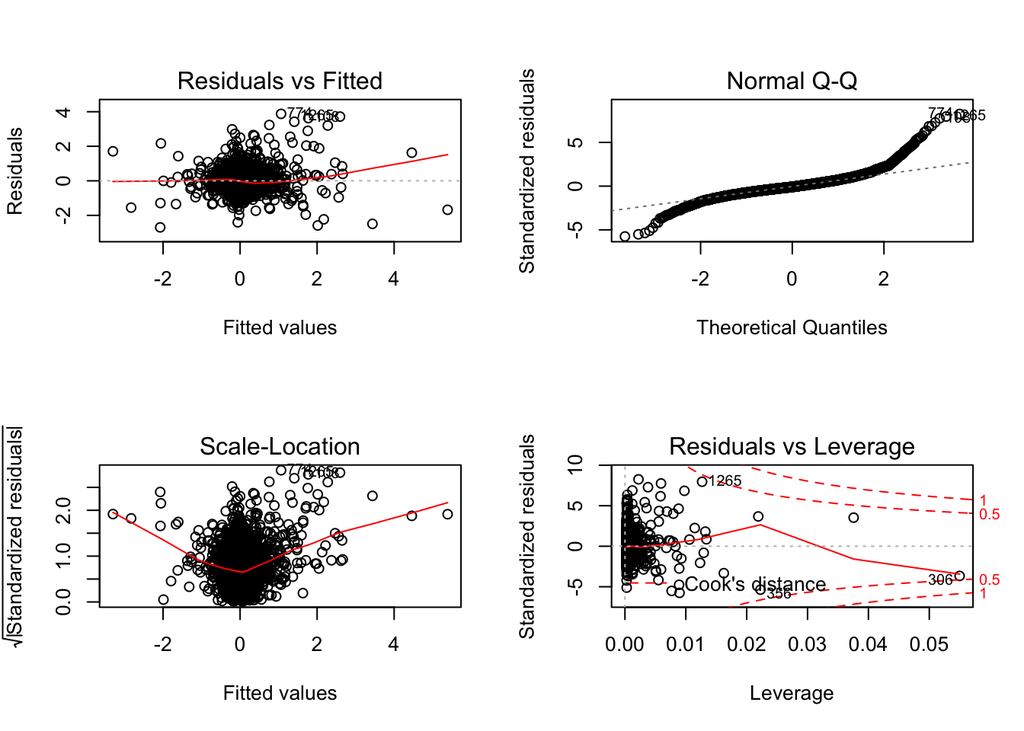

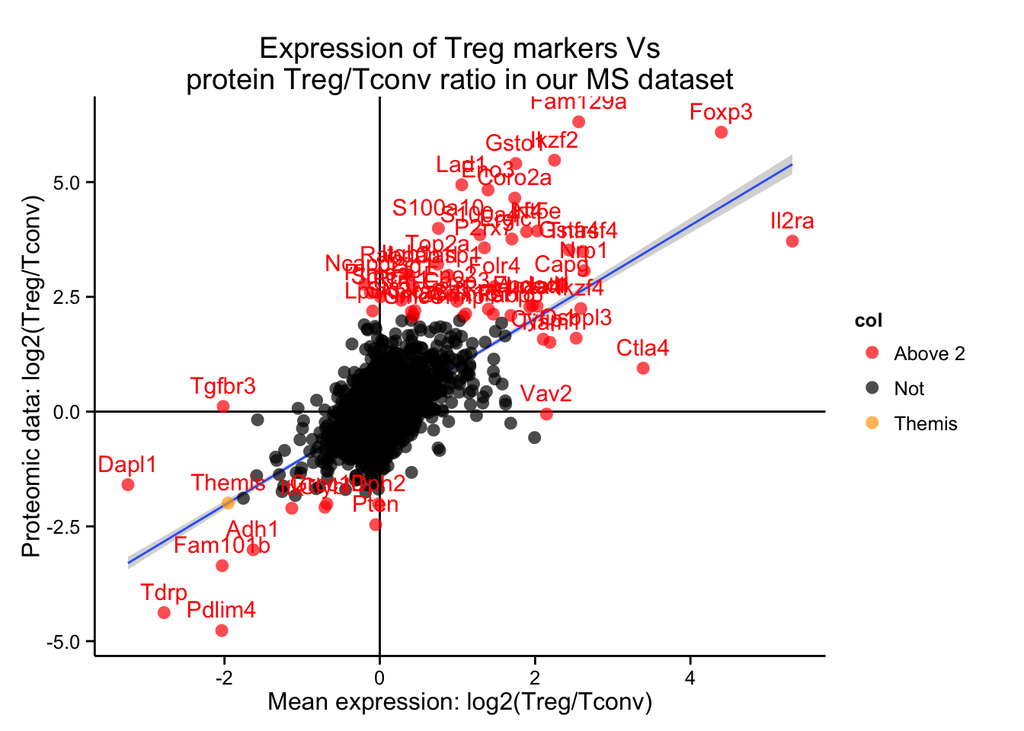

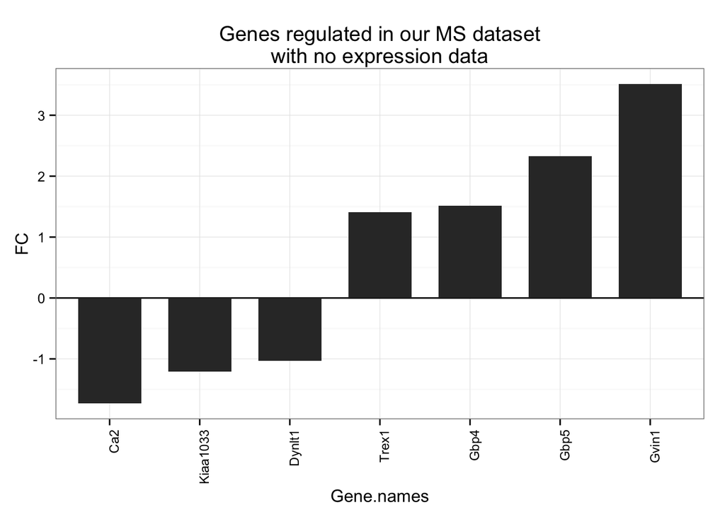

```
## Pres
##     not in our MS dataset Present in our MS dataset
##                     16852                      3818
```

There are 3818 unique genes that are present in the expression table and quantified in our MS dataset. There are 7 proteins that are regulated in our dataset and not present in the expression dataset. These are presented in the previous figure.

The table “ExpressionData//signatureFoxp3-V2.csv” contains the initial expression data with an additional column stating if the gene is quantified in our MS dataset.

The table “TableAll_20151126” contains our result table with the additional columns, including a “mapping” column that is the first Majority protein ID that I use to merge the other datasets to ours.

# Comparison with the proteomic dataset

Supplemental Table 1: Calculated dataset of proteins differentially expressed between Treg cells and Tconv cells.

I use all the protein accessions in the column “Accession” as input in Uniprot ID mapper to get all possible protein accessions of these proteins: “uniprot-yourlist%3AM201511302JVB080VYT-ProtMSinput.tab”.

```
##
## Call:
## lm(formula = tab1$FC ~ tab1$ProteomicRatioTregTconv)
##
## Residuals:
##     Min      1Q  Median      3Q     Max
## -2.7896 -0.1988 -0.0283  0.1460  4.5515
##
## Coefficients:
##                               Estimate Std. Error t value Pr(>|t|)
## (Intercept)                  -0.023218   0.007194  -3.227  0.00126 **
## tab1$ProteomicRatioTregTconv  0.773371   0.014050  55.044  < 2e-16 ***
## ---
## Signif. codes:  0 '***' 0.001 '**' 0.01 '*' 0.05 '.' 0.1 ' ' 1
##
## Residual standard error: 0.4298 on 3694 degrees of freedom
## Multiple R-squared:  0.4506, Adjusted R-squared:  0.4505
## F-statistic:  3030 on 1 and 3694 DF,  p-value: < 2.2e-16
```

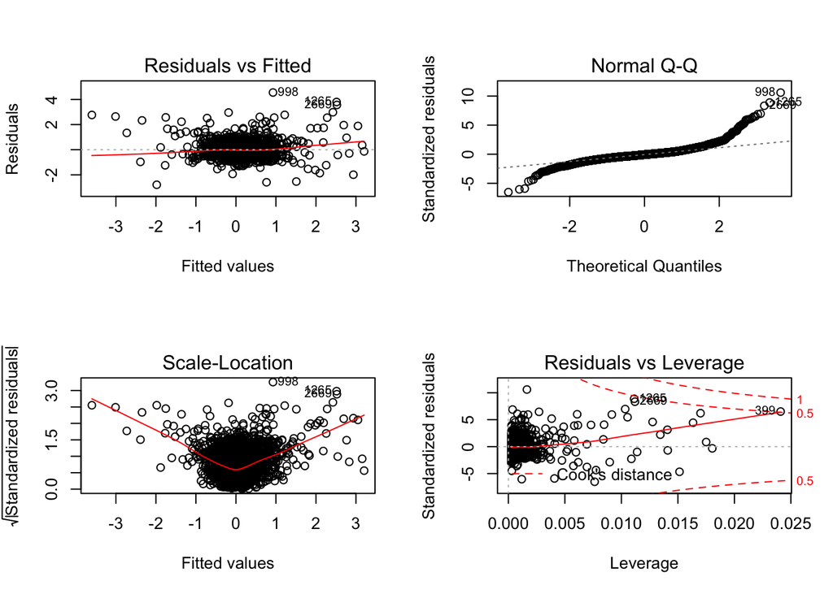

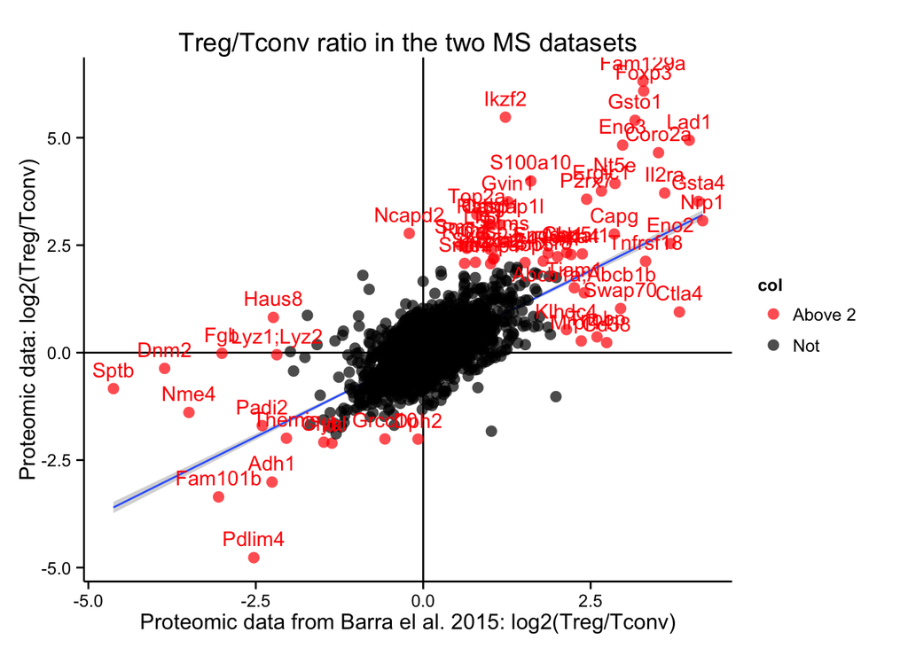

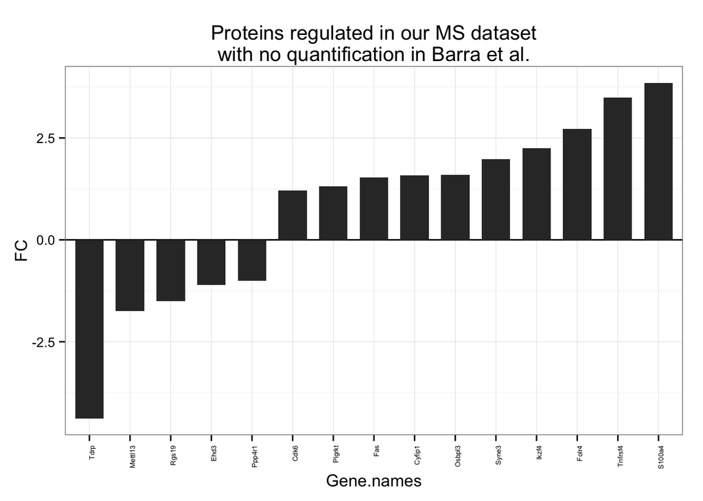

```
## Pres
##     not in our MS dataset Present in our MS dataset
##                      1543                      3775
```

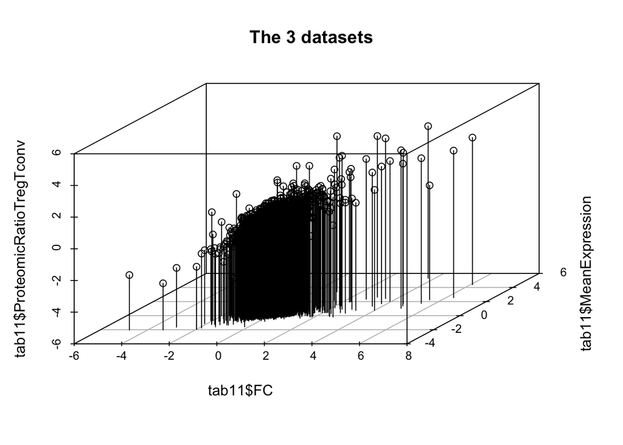

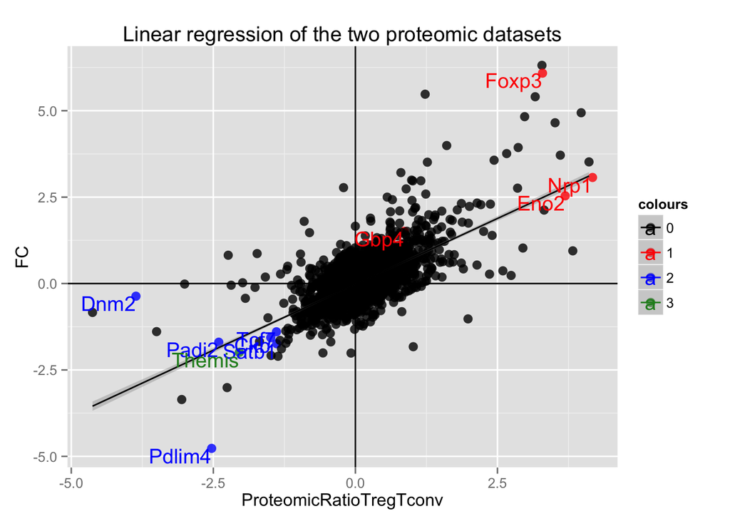

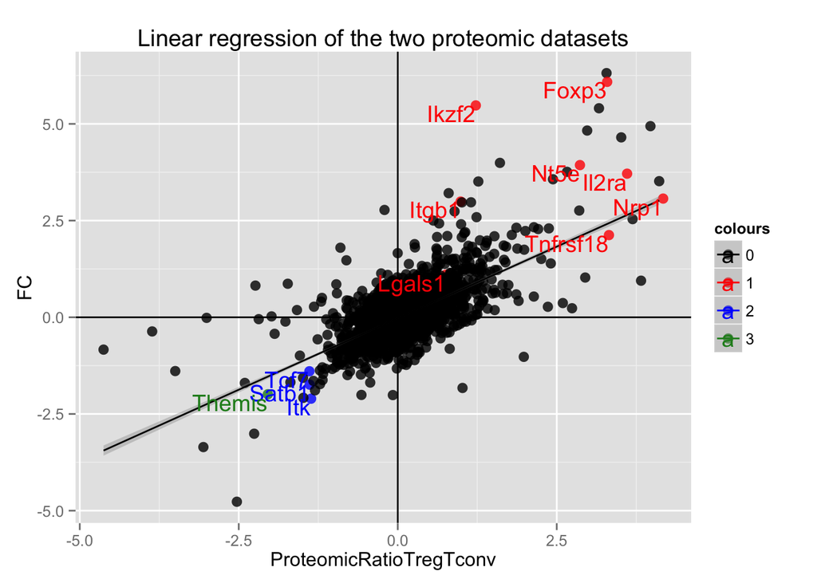

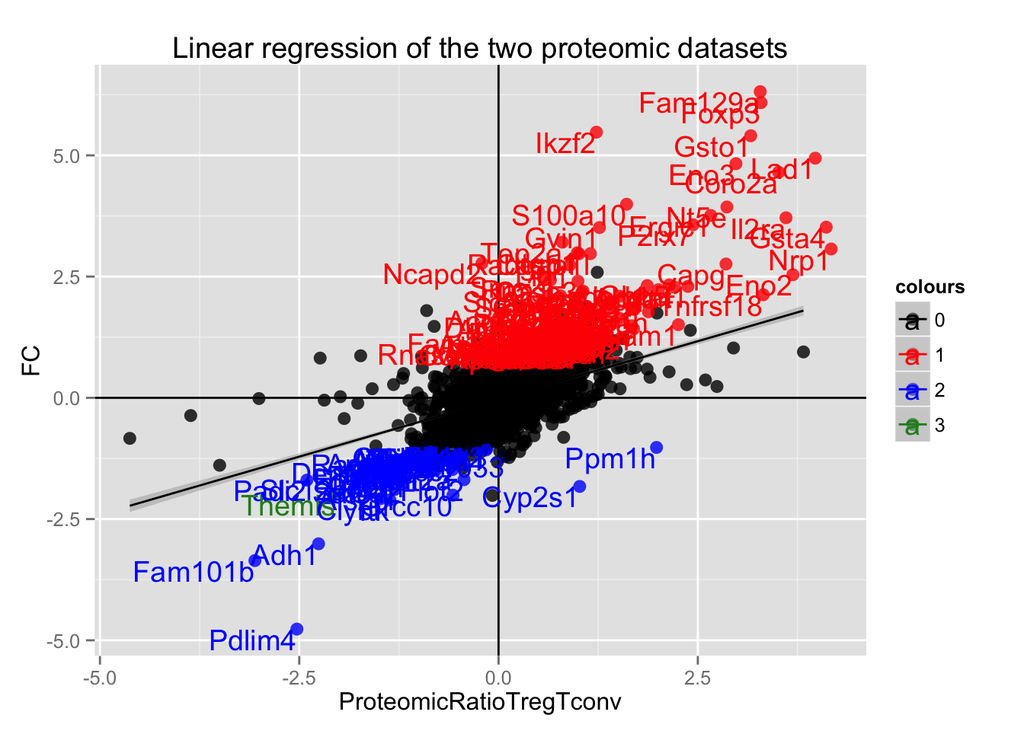

There are 3696 unique proteins that are present in the two tables. 15 proteins are regulated in our dataset and are not in the Barra et al. dataset. In total, 470 proteins are quantified in our dataset and absent of Barra et al. table. There are 3454 proteins quantified in teh 3 datasets.